# Part I and II Dimensionality Reduction

KIpsang

2/6/2022

# Marketing Analysis.

## 1. Main objective:

- Getting the most relevant marketing strategies that will result in the highest number of sales ( Total price tax inclusive) ### Specific Objectives
- Reduce highly dimensional datasets to lower dimensions for easy interpratation and analysis while assessing the attributes carrying core information in our dataset.
- Getting important attributes from the dataset.
- Getting associations within the transactions that will uncover important relationships for effective marketing.
- Checking for anomalies in the sales dataset for the sole purpose of fraud detection.

## 2. Data Inspection.

```r
library(data.table)
df<-fread("http://bit.ly/CarreFourDataset")
head(df)
```

```
##     Invoice ID Branch Customer type Gender           Product line Unit price
## 1: 750-67-8428      A        Member Female      Health and beauty      74.69
## 2: 226-31-3081      C        Normal Female Electronic accessories      15.28
## 3: 631-41-3108      A        Normal   Male     Home and lifestyle      46.33
## 4: 123-19-1176      A        Member   Male      Health and beauty      58.22
## 5: 373-73-7910      A        Normal   Male      Sports and travel      86.31
## 6: 699-14-3026      C        Normal   Male Electronic accessories      85.39
##    Quantity     Tax      Date  Time     Payment   cogs gross margin percentage
## 1:        7 26.1415  1/5/2019 13:08     Ewallet 522.83                4.761905
## 2:        5  3.8200  3/8/2019 10:29        Cash  76.40                4.761905
## 3:        7 16.2155  3/3/2019 13:23 Credit card 324.31                4.761905
## 4:        8 23.2880 1/27/2019 20:33     Ewallet 465.76                4.761905
## 5:        7 30.2085  2/8/2019 10:37     Ewallet 604.17                4.761905
## 6:        7 29.8865 3/25/2019 18:30     Ewallet 597.73                4.761905
##    gross income Rating    Total
## 1:      26.1415    9.1 548.9715
## 2:       3.8200    9.6  80.2200
## 3:      16.2155    7.4 340.5255
## 4:      23.2880    8.4 489.0480
## 5:      30.2085    5.3 634.3785
## 6:      29.8865    4.1 627.6165
```

#### Checking for missing values

```r
# Checking for missing values
any(is.na.data.frame(df))
```

```
## [1] FALSE
```

```r
# There are no missing values
```

#### Checking for duplicated values

```r
# Checking for duplicated data
any(duplicated.data.frame(df))
```

```
## [1] FALSE
```

```r
# There are no duplicates in our dataset
```

#### Encoding categorical variables to nominal to perform PCA

```r
library("dplyr")
numerical<-select_if(df,is.numeric)
numerical
```

```
##       Unit price Quantity     Tax   cogs gross margin percentage gross income
##    1:      74.69        7 26.1415 522.83                4.761905      26.1415
##    2:      15.28        5  3.8200  76.40                4.761905       3.8200
##    3:      46.33        7 16.2155 324.31                4.761905      16.2155
##    4:      58.22        8 23.2880 465.76                4.761905      23.2880
##    5:      86.31        7 30.2085 604.17                4.761905      30.2085
##   ---
##  996:      40.35        1  2.0175  40.35                4.761905       2.0175
##  997:      97.38       10 48.6900 973.80                4.761905      48.6900
##  998:      31.84        1  1.5920  31.84                4.761905       1.5920
##  999:      65.82        1  3.2910  65.82                4.761905       3.2910
## 1000:      88.34        7 30.9190 618.38                4.761905      30.9190
##       Rating     Total
##    1:    9.1  548.9715
##    2:    9.6   80.2200
##    3:    7.4  340.5255
##    4:    8.4  489.0480
##    5:    5.3  634.3785
##   ---
##  996:    6.2   42.3675
##  997:    4.4 1022.4900
##  998:    7.7   33.4320
##  999:    4.1   69.1110
## 1000:    6.6  649.2990
```

```r
# Selecting non numeric columns
head(df)
```

```
##     Invoice ID Branch Customer type Gender           Product line Unit price
## 1: 750-67-8428      A        Member Female      Health and beauty      74.69
## 2: 226-31-3081      C        Normal Female Electronic accessories      15.28
## 3: 631-41-3108      A        Normal   Male     Home and lifestyle      46.33
## 4: 123-19-1176      A        Member   Male      Health and beauty      58.22
## 5: 373-73-7910      A        Normal   Male      Sports and travel      86.31
## 6: 699-14-3026      C        Normal   Male Electronic accessories      85.39
##    Quantity     Tax      Date  Time     Payment   cogs gross margin percentage
## 1:        7 26.1415  1/5/2019 13:08     Ewallet 522.83                4.761905
## 2:        5  3.8200  3/8/2019 10:29        Cash  76.40                4.761905
## 3:        7 16.2155  3/3/2019 13:23 Credit card 324.31                4.761905
## 4:        8 23.2880 1/27/2019 20:33     Ewallet 465.76                4.761905
## 5:        7 30.2085  2/8/2019 10:37     Ewallet 604.17                4.761905
## 6:        7 29.8865 3/25/2019 18:30     Ewallet 597.73                4.761905
##    gross income Rating    Total
## 1:      26.1415    9.1 548.9715
## 2:       3.8200    9.6  80.2200
## 3:      16.2155    7.4 340.5255
## 4:      23.2880    8.4 489.0480
## 5:      30.2085    5.3 634.3785
## 6:      29.8865    4.1 627.6165
```

```r
# Caret package for dummy variables
library(caret)
# Encoding using Dummy variables and excluding unique ID and date time data
dums<-dummyVars("~.",data=df[,c(-1,-9,-10)])
dums
```

```
## Dummy Variable Object
##
## Formula: ~.
## <environment: 0x00000000343ef040>
## 13 variables, 0 factors
## Variables and levels will be separated by '.'
## A less than full rank encoding is used
```

```r
# Encoding.
new_df<-data.frame(predict(dums,newdata =df[,c(-1,-9,-10)]))
new_df
```

```
##      BranchA BranchB BranchC X.Customer.type.Member X.Customer.type.Normal
## 1          1       0       0                      1                      0
## 2          0       0       1                      0                      1
## 3          1       0       0                      0                      1
## 4          1       0       0                      1                      0
## 5          1       0       0                      0                      1
## 6          0       0       1                      0                      1
## 7          1       0       0                      1                      0
## 8          0       0       1                      0                      1
## 9          1       0       0                      1                      0
## 10         0       1       0                      1                      0
## 11         0       1       0                      1                      0
## 12         0       1       0                      1                      0
## 13         1       0       0                      0                      1
## 14         1       0       0                      0                      1
```

[output cut: 6992 more lines]

```r
# Dimensionality Reduction technique
# Will use PCA so as to understand the variance displayed by each feature
reduced_df<-prcomp(new_df,center = TRUE)
# Since prcomp uses single value decomposition that tests each points covariance and correlation to each other.
reduced_df$sdev
```

```
##  [1] 3.403819e+02 2.053220e+01 1.719967e+00 1.246753e+00 7.268821e-01
##  [6] 6.944099e-01 5.945089e-01 5.811926e-01 5.690861e-01 5.568613e-01
## [11] 4.180209e-01 4.106769e-01 4.077796e-01 4.004978e-01 3.904585e-01
## [16] 3.316253e-14 3.958663e-15 3.729380e-15 4.310238e-16 1.295179e-16
## [21] 1.009774e-16 7.798827e-17 1.648208e-17 1.265091e-33
```

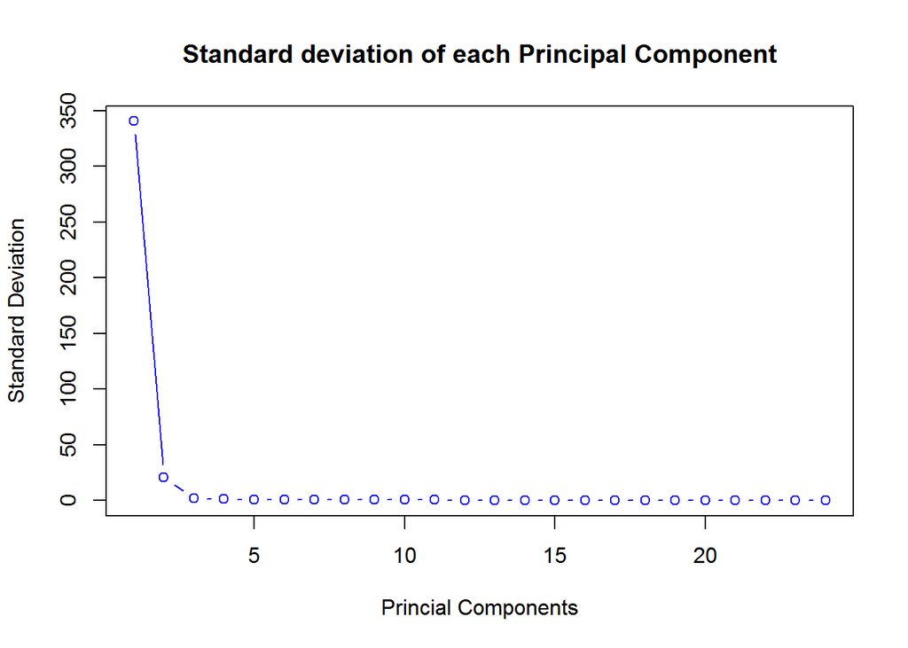

```r
# Checking the standard deviation of each PC
plot(reduced_df$sdev,main="Standard deviation of each Principal Component",ylab = "Standard Deviation",xlab = "Princial Components",type = "bar",col="blue")
```

```r
library(factoextra)
# Getting the sum of square distances from the projected point in our data
eigen_values<-get_eigenvalue(reduced_df)
eigen_values
```

```
##          eigenvalue variance.percent cumulative.variance.percent
## Dim.1  1.158598e+05     9.963088e+01                    99.63088
## Dim.2  4.215713e+02     3.625202e-01                    99.99340
## Dim.3  2.958285e+00     2.543907e-03                    99.99595
## Dim.4  1.554394e+00     1.336664e-03                    99.99728
## Dim.5  5.283577e-01     4.543485e-04                    99.99774
## Dim.6  4.822052e-01     4.146608e-04                    99.99815
## Dim.7  3.534408e-01     3.039330e-04                    99.99846
## Dim.8  3.377848e-01     2.904700e-04                    99.99875
## Dim.9  3.238590e-01     2.784948e-04                    99.99903
## Dim.10 3.100945e-01     2.666584e-04                    99.99929
## Dim.11 1.747415e-01     1.502648e-04                    99.99944
## Dim.12 1.686555e-01     1.450313e-04                    99.99959
## Dim.13 1.662842e-01     1.429921e-04                    99.99973
## Dim.14 1.603985e-01     1.379309e-04                    99.99987
## Dim.15 1.524578e-01     1.311025e-04                   100.00000
## Dim.16 1.099753e-27     9.457064e-31                   100.00000
## Dim.17 1.567101e-29     1.347591e-32                   100.00000
## Dim.18 1.390828e-29     1.196009e-32                   100.00000
## Dim.19 1.857815e-31     1.597584e-34                   100.00000
## Dim.20 1.677488e-32     1.442516e-35                   100.00000
## Dim.21 1.019644e-32     8.768181e-36                   100.00000
## Dim.22 6.082171e-33     5.230218e-36                   100.00000
## Dim.23 2.716589e-34     2.336066e-37                   100.00000
## Dim.24 1.600456e-66     1.376274e-69                   100.00000
```

```r
# We get to understand from these that dimension 1 or PCA 1 explains almost 99 % of all the variance in my dataset
```

```r
summary(reduced_df)
```

```
## Importance of components:
##                             PC1      PC2     PC3     PC4    PC5    PC6    PC7
## Standard deviation     340.3819 20.53220 1.71997 1.24675 0.7269 0.6944 0.5945
## Proportion of Variance   0.9963  0.00363 0.00003 0.00001 0.0000 0.0000 0.0000
## Cumulative Proportion    0.9963  0.99993 0.99996 0.99997 1.0000 1.0000 1.0000
##                           PC8    PC9   PC10  PC11   PC12   PC13   PC14   PC15
## Standard deviation     0.5812 0.5691 0.5569 0.418 0.4107 0.4078 0.4005 0.3905
## Proportion of Variance 0.0000 0.0000 0.0000 0.000 0.0000 0.0000 0.0000 0.0000
## Cumulative Proportion  1.0000 1.0000 1.0000 1.000 1.0000 1.0000 1.0000 1.0000
##                             PC16      PC17      PC18     PC19      PC20
## Standard deviation     3.316e-14 3.959e-15 3.729e-15 4.31e-16 1.295e-16
## Proportion of Variance 0.000e+00 0.000e+00 0.000e+00 0.00e+00 0.000e+00
## Cumulative Proportion  1.000e+00 1.000e+00 1.000e+00 1.00e+00 1.000e+00
##                            PC21      PC22      PC23      PC24
## Standard deviation     1.01e-16 7.799e-17 1.648e-17 1.265e-33
## Proportion of Variance 0.00e+00 0.000e+00 0.000e+00 0.000e+00
## Cumulative Proportion  1.00e+00 1.000e+00 1.000e+00 1.000e+00
```

### An importanct factor was noted that in formulating dummy variables it recreated varibales with no variablility that is ranging between 0 and 1 and since PCA maximized on utilizing variablities , i am resulted to embarking on my numerical variables to carry out PCA effectively.

```r
# This set seemed to have an anomaly as it was preventing scalability in the pca function. there is no variability in this column
unique(df$`gross margin percentage`)
```

```
## [1] 4.761905
```